# Project 1

Fernando Villarroel

This assignment is answering the questions detailed in the questionary. it is completed in a single R markdown document, and later processed by knitr and transformed into an HTML file.

#### Loading and preprocessing the data

The data is loaded in a data.frame with the name of *activity*, the Class of every column is assigned in this stage, also the scientific notation is “turn off”:

```r
activity<-read.csv("activity.csv",colClasses=c("numeric","POSIXct","numeric"))
options(scipen=999)
```

#### What is mean total number of steps taken per day?

Firt is calculated the total steps taken per day and it is saved in a data.frame with the name *DailyActSumDF*.

The **mean** and **median** total number of steps taken per day are calculated and stored in the variables *DailyActMean* and *DailyActMedian* respectivily.

```r
DailyActSum<-tapply(activity$steps,activity$date,sum,na.rm=T)
DailyNames<-names(DailyActSum)
DailyActSum<-as.numeric(DailyActSum)
DailyActSumDF<-data.frame(Date=DailyNames,TotalSteps=DailyActSum)
DailyActMean<-round(mean(DailyActSum,na.rm=T),0)
DailyActMedian<-round(median(DailyActSum,na.rm=T),0)
```

The Plot is builded using *ggplot2*.

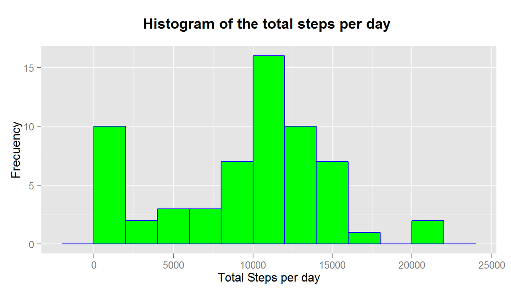

```r
library(ggplot2)

gh<-ggplot(DailyActSumDF,aes(x=TotalSteps))+
  geom_histogram(binwidth=2000,color="blue",fill="green")+
  ggtitle("Histogram of the total steps per day \n ") +
  theme(plot.title = element_text(lineheight=.8, face="bold"))+
  labs(x = "Total Steps per day", y = "Frecuency")

print(gh)
```

```r
png("./figures/1-DailyActSum.png")
print(gh)
dev.off()
```

The the mean total number of steps taken per day is: **9354**.  
The the median total number of steps taken per day is **10395**.

#### What is the average daily activity pattern?

Firt is calculated the average steps taken per interval across all the days and it is saved in a data.frame with the name *IntervalActMeanDF*.

The interval in which is taken the maximun numbers of steps is calculates and stored in the variable **MaxInterval**.

```r
IntervalActMean<-tapply(activity$steps,activity$interval,mean,na.rm=T)
IntervalNames<-names(IntervalActMean)
IntervalActMean<-as.numeric(IntervalActMean)
IntervalActMeanDF<-data.frame(Interval=as.numeric(IntervalNames),AverageSteps=IntervalActMean)
IntervalActMax<-max(IntervalActMean,na.rm=T)
IntervalActMaxLog<-IntervalActMean==IntervalActMax
MaxInterval<-IntervalNames[IntervalActMaxLog]
```

The Plot is builded using *ggplot2*.

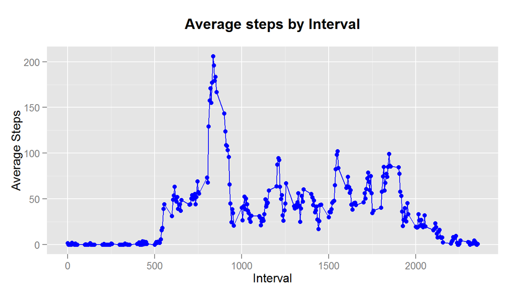

```r
library(ggplot2)

gi<-ggplot(IntervalActMeanDF,aes(x=Interval,y=AverageSteps))+
  geom_point(color="blue",size=2)+
  geom_path(color="blue")+
  ggtitle("Average steps by Interval\n ") +
  theme(plot.title = element_text(lineheight=.8, face="bold"))+
  labs(y = "Average Steps")

print(gi)
```

```r
png("./figures/2-IntervalActMean.png")
print(gi)
dev.off()
```

On average across all the days in the dataset the 5-minute interval which contains the maximum number of step is the: **835**.

#### Imputing missing values

1. To calculate the number of missing values is used the functions *is.na* and *sum*, the number is stored in the variable *isnanumber*.

```r
isnanumber<-sum(is.na(activity$steps))
```

The number of missing values in the dataset is: **2304**

2. The strategy for filling the missing values in the dataset is use the mean for that 5-minute interval in every missed value.
3. The new dataset that is equal to the original dataset but with the missing data filled with the strategy described in point 2 is *ActNoNA*, to create it was used a loop.

```r
ActNoNA<-activity
for(i in 1:nrow(ActNoNA)){
  isna<-is.na(ActNoNA[i,1])
  if(isna==T){
    IntLog<-IntervalNames==ActNoNA[i,3]
    ActNoNA[i,1]<-round(IntervalActMean[IntLog],0)
  }

}
```

4. To create the new **histogram** and calculate the new **mean** and **mediam** are used the same steps as the first task.

```r
DailyActNoNASum<-tapply(ActNoNA$steps,ActNoNA$date,sum,na.rm=F)
DailyNoNANames<-names(DailyActNoNASum)
DailyActNoNASum<-as.numeric(DailyActNoNASum)
DailyActNoNASumDF<-data.frame(Date=DailyNoNANames,TotalSteps=DailyActNoNASum)
DailyActNoNAMean<-round(mean(DailyActNoNASum,na.rm=T),0)
DifMean<-abs(DailyActNoNAMean-DailyActMean)
DailyActNoNAMedian<-round(median(DailyActNoNASum,na.rm=T),0)
DifMedian<-abs(DailyActNoNAMedian-DailyActMedian)
```

The Plot is builded using *ggplot2*.

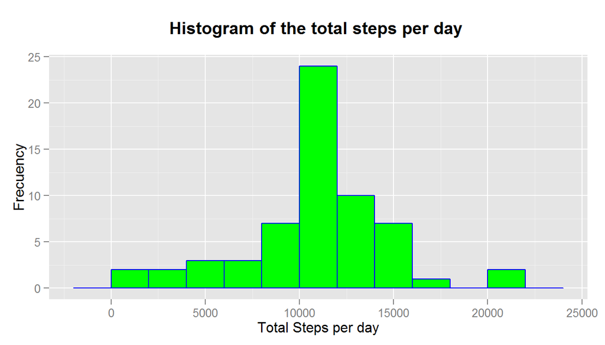

```r
library(ggplot2)

ghnona<-ggplot(DailyActNoNASumDF,aes(x=TotalSteps))+
  geom_histogram(binwidth=2000,color="blue",fill="green")+
  ggtitle("Histogram of the total steps per day \n ") +
  theme(plot.title = element_text(lineheight=.8, face="bold"))+
  labs(x = "Total Steps per day", y = "Frecuency")

print(ghnona)
```

```r
png("./figures/3-DailyActNoNASum.png")
print(gh)
dev.off()
```

The new mean total number of steps taken per day is: **10766**, the difference with the previous value is **1412** steps.

The new median total number of steps taken per day is **10762**, the difference with the previous value is **367** steps.

The main differences with the data sets with missing values and the data set without missing values is that the frequency of the average values increase around 10 points.

#### Are there differences in activity patterns between weekdays and weekends?

1. A new factor variable in the dataset with two levels - “weekday” and “weekend” indicating whether a given date is a weekday or weekend day has been create, the column has the name of *TypeDay*.

```r
Sys.setlocale("LC_TIME", "C")
```

```
## [1] "C"
```

```r
ActNoNA$weekday<-as.factor(weekdays(ActNoNA$date))
TypeDay<-character()
for(i in 1:nrow(ActNoNA)){
  if(ActNoNA[i,4]=="Monday"|ActNoNA[i,4]=="Tuesday"|ActNoNA[i,4]=="Wednesday"|ActNoNA[i,4]=="Thursday"|ActNoNA[i,4]=="Friday"){
    TypeDay[i]<-"Weekday"
  } else {TypeDay[i]<-"Weekend"}
}
ActNoNA$TypeDay<-TypeDay
```

2. First the data is prepare in a data set in which the first column has the 5-minute interval -*Interval*- the second column has the average for that interval depending of the type of day -*Mean*- and the third column has the type of day, Weekday or Weekend -*TypeDay*-.

```r
IntercalActNoNASTD<-split(ActNoNA,ActNoNA$TypeDay)

IntervalActNoNAMeanWD<-tapply(IntercalActNoNASTD[[1]]$steps,IntercalActNoNASTD[[1]]$interval,mean,na.rm=T)
IntervalNoNANamesWD<-names(IntervalActNoNAMeanWD)
IntervalActNoNAMeanWD<-as.numeric(IntervalActNoNAMeanWD)
IntervalActNoNAMeanDFWD<-data.frame(Interval=as.numeric(IntervalNoNANamesWD),AverageSteps=IntervalActNoNAMeanWD,TypeDay="Weekday")

IntervalActNoNAMeanWE<-tapply(IntercalActNoNASTD[[2]]$steps,IntercalActNoNASTD[[2]]$interval,mean,na.rm=T)
IntervalNoNANamesWE<-names(IntervalActNoNAMeanWE)
IntervalActNoNAMeanWE<-as.numeric(IntervalActNoNAMeanWE)
IntervalActNoNAMeanDFWE<-data.frame(Interval=as.numeric(IntervalNoNANamesWE),AverageSteps=IntervalActNoNAMeanWE,TypeDay="Weekend")

IntervalActNoNAMeanDF<-rbind(IntervalActNoNAMeanDFWD,IntervalActNoNAMeanDFWE)
```

The Plot is builded using *ggplot2*.

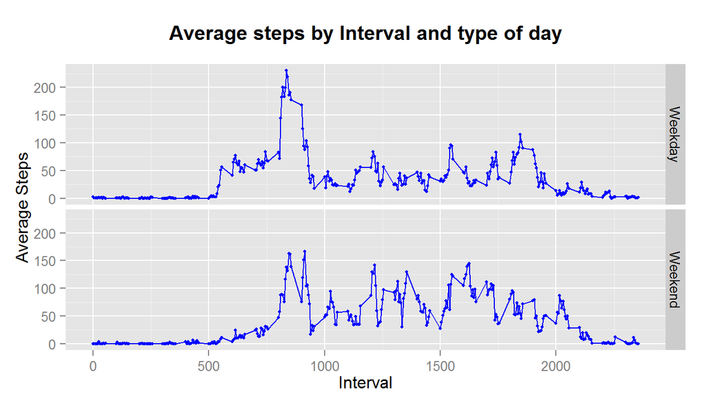

```r
library(ggplot2)

gtd<-ggplot(IntervalActNoNAMeanDF,aes(x=Interval,y=AverageSteps))+
  geom_point(color="blue",size=1)+
  geom_path(color="blue")+
  ggtitle("Average steps by Interval and type of day\n ") +
  facet_grid(TypeDay~.)+
  theme(plot.title = element_text(lineheight=.8, face="bold"))+
  labs(y = "Average Steps")

print(gtd)
```

```r
png("./figures/4-IntervalActNoNAMean.png")
print(gh)
dev.off()
```